# Modèles statistiques pour les données cliniques et de santé — ANOVA

Cours (p. 66–80) et exercices guidés avec R

d’après V. Monbet, Université de Rennes

# 1 Comment utiliser ce document

- Les blocs de **cours** reprennent les éléments des diapositives (modèles, statistiques de test, hypothèses) et les illustrent avec du code R exécutable.
- Les **exercices** sont des blocs `eval=FALSE` à compléter : remplacez les `...` par votre code, puis passez `eval=TRUE` pour les exécuter.
- Les **corrigés** sont regroupés en fin de document (section « Corrigés ») : essayez d’abord seul·e.
- Seul R de base est nécessaire (aucun package à installer).

Jeux de données utilisés :

- `PlantGrowth` (fourni avec R) : poids sec de plantes (`weight`) selon 3 groupes (`ctrl`, `trt1`, `trt2`), déjà vu dans le cours.
- `ToothGrowth` (fourni avec R) : croissance dentaire de cobayes selon la dose et le type de supplément.
- `diet` : jeu de données **simulé** ici, inspiré des diapositives (perte de poids selon 3 régimes A, B, C et le sexe).

```r
# Données simulées : 3 régimes x 2 sexes, 13 personnes par cellule (N = 78)
diet <- data.frame(
  diet.type = factor(rep(c("A", "B", "C"), each = 26)),
  gender    = factor(rep(rep(c("Female", "Male"), each = 13), times = 3))
)
mu_cell <- c(A.Female = 2.9, A.Male = 3.8,
             B.Female = 3.0, B.Male = 4.3,
             C.Female = 6.7, C.Male = 4.4)
diet$weight.loss <- rnorm(nrow(diet),
                          mean = mu_cell[paste(diet$diet.type, diet$gender, sep = ".")],
                          sd = 2.3)
head(diet)
```

|  | diet.type | gender | weight.loss |
| --- | --- | --- | --- |
| 1 | A | Female | 4.327740 |
| 2 | A | Female | 2.981975 |
| 3 | A | Female | 4.678255 |
| 4 | A | Female | 5.826725 |
| 5 | A | Female | 3.753243 |
| 6 | A | Female | 2.525435 |

```r
str(diet)
```

```
## 'data.frame':    78 obs. of  3 variables:
##  $ diet.type  : Factor w/ 3 levels "A","B","C": 1 1 1 1 1 1 1 1 1 1 ...
##  $ gender     : Factor w/ 2 levels "Female","Male": 1 1 1 1 1 1 1 1 1 1 ...
##  $ weight.loss: num  4.33 2.98 4.68 5.83 3.75 ...
```

# 2 Comparer deux moyennes : le point de vue « modèle » (p. 66)

On veut comparer deux groupes indépendants (par exemple « contrôle » et « traité ») :

$$x_i^{(1)} = \mu + \epsilon_i,\quad
i=1,\dots,n \qquad\qquad x_j^{(2)} = \mu + \Delta + \eta_j,\quad
j=1,\dots,m$$

où $\Delta$ est l’effet du traitement par rapport au contrôle. On teste

$$H_0 : \Delta = 0 \quad\text{contre}\quad
H_1 : \Delta \neq 0 \;(\text{ou } \Delta<0,\
\Delta>0).$$

Avec des variances égales, c’est le test de Student à deux échantillons. Mais c’est **aussi** un modèle linéaire : le coefficient associé au groupe « traité » est exactement $\hat\Delta$.

```r
pg2 <- subset(PlantGrowth, group %in% c("ctrl", "trt1"))
pg2$group <- droplevels(pg2$group)

t.test(weight ~ group, data = pg2, var.equal = TRUE)
```

```
##
##  Two Sample t-test
##
## data:  weight by group
## t = 1.1913, df = 18, p-value = 0.249
## alternative hypothesis: true difference in means between group ctrl and group trt1 is not equal to 0
## 95 percent confidence interval:
##  -0.2833003  1.0253003
## sample estimates:
## mean in group ctrl mean in group trt1
##              5.032              4.661
```

```r
summary(lm(weight ~ group, data = pg2))$coefficients
```

```
##             Estimate Std. Error  t value     Pr(>|t|)
## (Intercept)    5.032  0.2202177 22.85012 9.547128e-15
## grouptrt1     -0.371  0.3114349 -1.19126 2.490232e-01
```

## 2.1 Exercice 1 — Student, régression et ANOVA : même test ?

1. Réalisez le test de Student (variances égales) de `weight` entre `ctrl` et `trt1`, puis une ANOVA `aov(weight ~ group, data = pg2)`.
2. Comparez la p-value des deux tests. Vérifiez numériquement que la statistique $F$ de l’ANOVA est égale au carré de la statistique $t$.
3. Dans `lm`, que représente le coefficient `grouptrt1` ? Quel est son signe et pourquoi ?

```r
tt  <- t.test(..., var.equal = TRUE)
av  <- aov(..., data = pg2)
F_obs <- summary(av)[[1]][["F value"]][1]
c(t_au_carre = ..., F = F_obs)
```

# 3 ANOVA : principe (p. 67–69)

**ANOVA** = *ANalysis Of VAriance*, mais c’est un test de **différence de moyennes** entre $K$ groupes.

Notations : $K$ groupes, $n_k$ individus dans le groupe $k$, $x_{ik}$ = observation $i$ du groupe $k$, $N=\sum_k n_k$.

$$H_0 : \mu_1=\dots=\mu_K \qquad H_1 :
\exists\, k,k' \text{ tels que } \mu_k \neq
\mu_{k'}$$

L’idée : la variation totale (somme des carrés des écarts) se décompose en deux parties **orthogonales** :

- variabilité **intra-groupe** (fluctuations individuelles, « erreur ») : *Within SS*, notée $W$ ;
- variabilité **inter-groupe** (effet du traitement) : *Between SS*, notée $B$.

$$\underbrace{\sum_{k}\sum_{i}(x_{ik}-\bar
x)^2}_{SST}=\underbrace{\sum_k n_k(\bar x_k-\bar
x)^2}_{B}+\underbrace{\sum_k\sum_i(x_{ik}-\bar x_k)^2}_{W}$$

Si la variabilité inter-groupe est grande **relativement** à la variabilité intra-groupe, au moins deux moyennes sont significativement différentes. Le test de Fisher regarde le rapport $B/W$ (corrigé par les degrés de liberté) : plus $F$ est grand, plus la différence est significative.

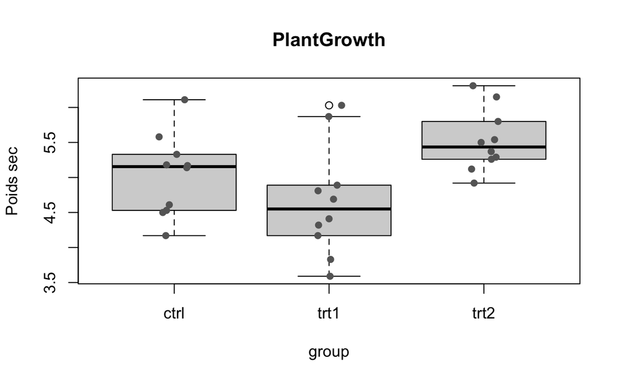

```r
boxplot(weight ~ group, data = PlantGrowth, main = "PlantGrowth", ylab = "Poids sec")
stripchart(weight ~ group, data = PlantGrowth, vertical = TRUE, method = "jitter",
           pch = 16, col = "grey40", add = TRUE)
```

## 3.1 Exercice 2 — Décomposition de la somme des carrés « à la main »

Sur `PlantGrowth` :

1. Calculez la moyenne générale, les moyennes par groupe et les effectifs.
2. Calculez $SST$, $B$ et $W$. Vérifiez que $SST = B + W$.
3. Calculez $F=\dfrac{B/(K-1)}{W/(N-K)}$ et la p-value avec `pf(..., lower.tail = FALSE)`.
4. Comparez avec `summary(aov(weight ~ group, data = PlantGrowth))`.

```r
y <- PlantGrowth$weight
g <- PlantGrowth$group
N <- length(y); K <- nlevels(g)
ybar   <- mean(y)
ybar_k <- tapply(y, g, mean)
n_k    <- tapply(y, g, length)

SST <- sum((y - ybar)^2)
B   <- ...
W   <- ...
c(SST = SST, B_plus_W = B + W)

F_obs <- ...
p_val <- pf(F_obs, df1 = ..., df2 = ..., lower.tail = FALSE)
c(F = F_obs, p = p_val)
```

# 4 Pourquoi ne pas faire tous les tests deux à deux ? (p. 70)

Pour $m$ comparaisons **indépendantes** au niveau $\alpha$, la probabilité de rejeter au moins une fois $H_0$ alors qu’elle est vraie est

$$\alpha_m = 1-(1-\alpha)^m .$$

```r
m <- c(1, 3, 5, 10, 21)
data.frame(m = m, risque_global = round(1 - (1 - 0.05)^m, 2))
```

| m | risque_global |
| --- | --- |
| 1 | 0.05 |
| 3 | 0.14 |
| 5 | 0.23 |
| 10 | 0.40 |
| 21 | 0.66 |

On retrouve 0,14 ; 0,23 ; 0,40 ; 0,66 (diapositive 70). Le risque de première espèce n’est plus contrôlé à 5 % : le procédé est **anti-conservatif** (libéral).

## 4.1 Exercice 3 — Simulation de l’inflation du risque de première espèce

On simule 3 groupes de 10 observations suivant **la même** loi $\mathcal N(0,1)$ ($H_0$ est vraie), 2000 fois.

1. Estimez la proportion de simulations où l’ANOVA rejette $H_0$ au seuil 5 %. Que devrait-on trouver ?
2. Estimez la proportion de simulations où **au moins un** des 3 tests de Student deux à deux (sans correction) a une p-value < 0,05. Comparez avec $1-(1-0{,}05)^3$.
3. Refaites 2. avec la correction de Bonferroni (`p.adjust.method = "bonferroni"`).

```r
nsim <- 2000
res <- replicate(nsim, {
  d <- data.frame(y = rnorm(30), g = factor(rep(1:3, each = 10)))
  p_anova <- summary(aov(y ~ g, data = d))[[1]][["Pr(>F)"]][1]
  p_pair  <- pairwise.t.test(d$y, d$g, p.adjust.method = "none")$p.value
  p_bonf  <- pairwise.t.test(d$y, d$g, p.adjust.method = "bonferroni")$p.value
  c(anova = p_anova < 0.05,
    paires = any(p_pair < 0.05, na.rm = TRUE),
    bonferroni = any(p_bonf < 0.05, na.rm = TRUE))
})
rowMeans(res)
```

# 5 Le modèle de l’ANOVA à un facteur (p. 71–73)

On suppose $\epsilon_{ik}\overset{iid}{\sim}\mathcal N(0,\sigma^2)$.

- Sous $H_0$ : $x_{ik}=\mu+\epsilon_{ik}$.
- Sous $H_1$ : $x_{ik}=\mu+\Delta_k+\epsilon_{ik}$, avec la contrainte $\sum_k n_k\Delta_k=0$, où $\Delta_k$ est l’effet de la modalité $k$ du facteur.

Pour chaque modèle on peut estimer la variance résiduelle ; le test de Fisher compare ces deux estimations. La statistique du test est (diapositive 73)

$$F=\frac{N\,s^2_{\bar Y}}{s^2_p}\sim
F_{K-1,\,N-K}\quad\text{sous }H_0,$$

$$s^2_{\bar
Y}=\frac{1}{K-1}\sum_{k=1}^K\frac{n_k}{N}(\bar Y_k-\bar Y)^2,\qquad
s_p^2=\frac{1}{N-K}\sum_{k=1}^K (n_k-1)s_k^2 .$$

> **Remarque.** Sur la diapositive, le facteur devant $s_p^2$ est écrit $1/(K-1)$ ; pour que $F$ suive bien une loi de Fisher $F_{K-1,N-K}$ (et égale $\frac{B/(K-1)}{W/(N-K)}$), la variance poolée $s_p^2$ est normalisée par $N-K$, comme ci-dessus.

Illustration sur les données simulées `diet`, en ignorant d’abord le sexe :

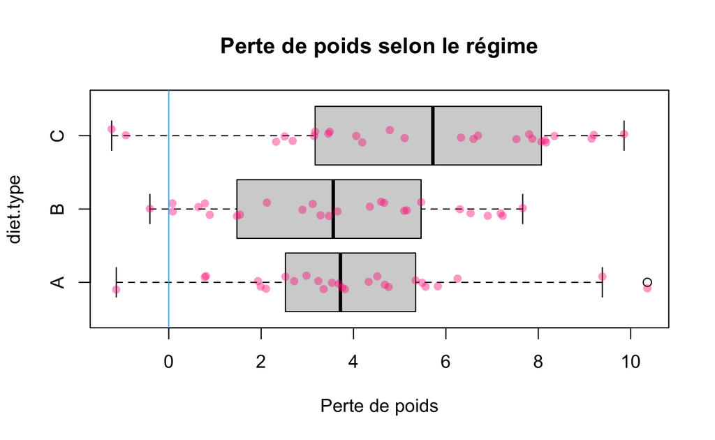

```r
boxplot(weight.loss ~ diet.type, data = diet, horizontal = TRUE,
        main = "Perte de poids selon le régime", xlab = "Perte de poids")
stripchart(weight.loss ~ diet.type, data = diet, method = "jitter",
           pch = 16, col = rgb(1, 0, 0.5, 0.4), add = TRUE)
abline(v = 0, col = "deepskyblue")
```

```r
fit1 <- aov(weight.loss ~ diet.type, data = diet)
summary(fit1)
```

```
##             Df Sum Sq Mean Sq F value Pr(>F)
## diet.type    2   46.0  23.024    3.21 0.0459 *
## Residuals   75  537.9   7.172
## ---
## Signif. codes:  0 '***' 0.001 '**' 0.01 '*' 0.05 '.' 0.1 ' ' 1
```

La table d’ANOVA donne : `Df` (degrés de liberté), `Sum Sq` ($B$ pour `diet.type`, $W$ pour `Residuals`), `Mean Sq` (somme des carrés / ddl), `F value` et `Pr(>F)`.

```r
model.tables(fit1, type = "means")     # moyennes par groupe
```

```
## Tables of means
## Grand mean
##
## 4.331746
##
##  diet.type
## diet.type
##     A     B     C
## 3.945 3.646 5.405
```

```r
coef(lm(weight.loss ~ diet.type, data = diet))  # contrastes (A = référence)
```

```
## (Intercept)  diet.typeB  diet.typeC
##   3.9451959  -0.2996585   1.4593073
```

## 5.1 Exercice 4 — Lire et interpréter une table d’ANOVA

1. Calculez à la main, à partir des moyennes de groupes, la statistique $F$ de `fit1` avec les formules de $s^2_{\bar Y}$ et $s^2_p$ ci-dessus. Vérifiez que vous retrouvez la valeur de `summary(fit1)`.
2. Calculez la part de variance expliquée par le régime : $\eta^2 = B/SST$.
3. Concluez en une phrase, dans le contexte de l’étude (au risque 5 %).

```r
y <- diet$weight.loss; g <- diet$diet.type
N <- length(y); K <- nlevels(g)
n_k <- tapply(y, g, length); m_k <- tapply(y, g, mean); v_k <- tapply(y, g, var)
ybar <- mean(y)

s2_Ybar <- ...
s2_p    <- ...
F_obs   <- N * s2_Ybar / s2_p
F_obs

eta2 <- ...
eta2
```

# 6 Vérification du modèle : analyse des résidus (p. 76)

Les résidus sont $\hat\epsilon_{ik}=Y_{ik}-\hat\mu-\hat\Delta_k = Y_{ik}-\bar Y_k$. L’ANOVA de Fisher suppose :

1. des résidus **gaussiens** (diagramme quantile-quantile, test de Shapiro-Wilk) ;
2. des variances **égales** dans les groupes (boîtes à moustaches des résidus, test de Bartlett) ;
3. des observations **indépendantes** (c’est le plan d’expérience qui le garantit).

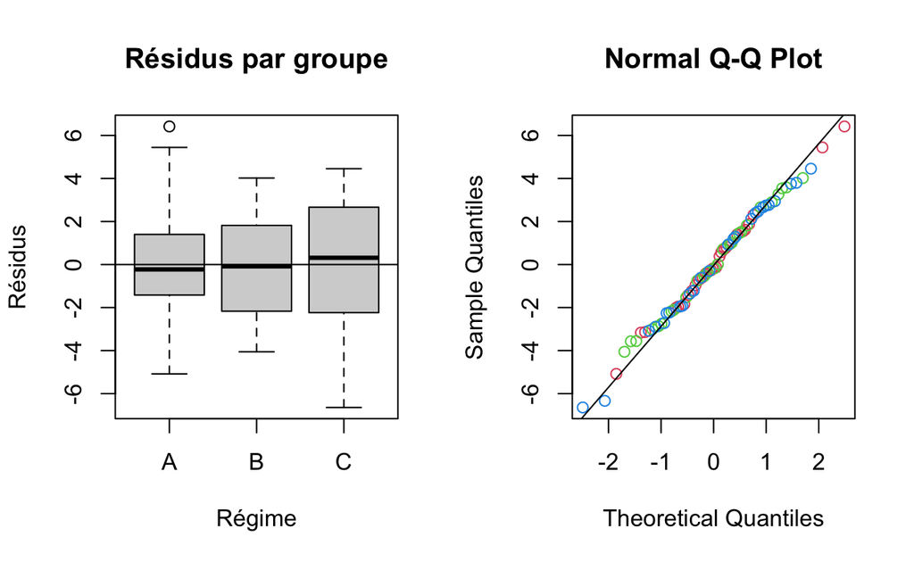

```r
diet$resid <- residuals(fit1)

par(mfrow = c(1, 2))
boxplot(resid ~ diet.type, data = diet, main = "Résidus par groupe",
        xlab = "Régime", ylab = "Résidus")
abline(h = 0)
qqnorm(diet$resid, main = "Normal Q-Q Plot",
       col = as.integer(diet$diet.type) + 1)
qqline(diet$resid)
```

```r
par(mfrow = c(1, 1))

shapiro.test(diet$resid)
```

```
##
##  Shapiro-Wilk normality test
##
## data:  diet$resid
## W = 0.99199, p-value = 0.9121
```

```r
bartlett.test(resid ~ diet.type, data = diet)
```

```
##
##  Bartlett test of homogeneity of variances
##
## data:  resid by diet.type
## Bartlett's K-squared = 1.3991, df = 2, p-value = 0.4968
```

> Rappel (p. 52) : sur de très petits échantillons, Shapiro-Wilk a peu de puissance ; il faut **toujours** regarder aussi le qq-plot. Le test de Bartlett est lui-même sensible à la non-normalité.

## 6.1 Exercice 5 — Valider les hypothèses sur `PlantGrowth`

1. Calculez les résidus de `aov(weight ~ group, data = PlantGrowth)`.
2. Tracez le qq-plot et réalisez le test de Shapiro-Wilk.
3. Testez l’égalité des variances avec `bartlett.test`. Les conditions d’application de l’ANOVA de Fisher sont-elles raisonnablement satisfaites ?

```r
fit_pg <- aov(weight ~ group, data = PlantGrowth)
r <- residuals(fit_pg)
qqnorm(...); qqline(...)
shapiro.test(...)
bartlett.test(...)
```

# 7 ANOVA de Welch : variances inégales (p. 74)

Dans l’ANOVA de Fisher, on suppose toutes les variances égales. L’ANOVA de Welch lève cette hypothèse : modèle $Y_{i(g)}=\mu_g+\epsilon_{i(g)}$ avec $\epsilon_{i(g)}\sim\mathcal N(0,\sigma_g^2)$, et les groupes sont pondérés par $w_g=n_g/s_g^2$. La statistique $F^\star$ suit approximativement une loi de Fisher$(G-1,\Delta)$ (le second degré de liberté est non entier et estimé).

```r
oneway.test(weight.loss ~ diet.type, data = diet, var.equal = FALSE)  # Welch
```

```
##
##  One-way analysis of means (not assuming equal variances)
##
## data:  weight.loss and diet.type
## F = 2.7868, num df = 2.00, denom df = 49.61, p-value = 0.07128
```

```r
oneway.test(weight.loss ~ diet.type, data = diet, var.equal = TRUE)   # = Fisher
```

```
##
##  One-way analysis of means
##
## data:  weight.loss and diet.type
## F = 3.2103, num df = 2, denom df = 75, p-value = 0.04595
```

## 7.1 Exercice 6 — Fisher ou Welch ?

On simule trois groupes de **même moyenne** mais d’écarts-types très différents et d’effectifs déséquilibrés :

```r
sim_het <- function() {
  data.frame(
    y = c(rnorm(10, 0, 1), rnorm(10, 0, 3), rnorm(40, 0, 6)),
    g = factor(rep(c("g1", "g2", "g3"), times = c(10, 10, 40)))
  )
}
```

1. Répétez 2000 fois la simulation et estimez la proportion de rejets de $H_0$ à 5 % pour l’ANOVA de Fisher et pour celle de Welch. $H_0$ est vraie : quel test respecte le mieux le niveau 5 % ?
2. Quel lien faites-vous avec le test de Student à variances différentes vu en cours (p. 62) ?

```r
res <- replicate(2000, {
  d <- sim_het()
  c(fisher = oneway.test(y ~ g, data = d, var.equal = TRUE)$p.value < 0.05,
    welch  = oneway.test(y ~ g, data = d, var.equal = FALSE)$p.value < 0.05)
})
rowMeans(res)
```

# 8 Plus de deux groupes sans hypothèse de normalité : Kruskal-Wallis (p. 75)

Le test de Kruskal-Wallis est l’analogue non paramétrique de l’ANOVA : on travaille sur les **rangs globaux** $R_{ik}$ des observations. Avec $V$ valeurs distinctes et $t_v$ le nombre de répétitions de la valeur $v$ (ex æquo), la statistique corrigée est

$$S=\frac{\dfrac{12}{N(N+1)}\sum_{k=1}^K
\dfrac{R_{k}^2}{n_k}-3(N+1)}{1-\dfrac{\sum_{v}(t_v^3-t_v)}{N^3-N}}\;\overset{H_0}{\approx}\;\chi^2_{K-1},$$

où $R_k=\sum_i R_{ik}$ est la somme des rangs du groupe $k$.

> Les diapositives écrivent $-3(N-1)$ et $\bar R_k$ au numérateur ; la forme classique, utilisée par `kruskal.test`, est celle ci-dessus (avec $N+1$ et la somme des rangs $R_k$).

```r
kruskal.test(weight.loss ~ diet.type, data = diet)
```

```
##
##  Kruskal-Wallis rank sum test
##
## data:  weight.loss by diet.type
## Kruskal-Wallis chi-squared = 5.8321, df = 2, p-value = 0.05415
```

```r
kruskal.test(weight ~ group, data = PlantGrowth)
```

```
##
##  Kruskal-Wallis rank sum test
##
## data:  weight by group
## Kruskal-Wallis chi-squared = 7.9882, df = 2, p-value = 0.01842
```

## 8.1 Exercice 7 — Kruskal-Wallis à la main

1. Calculez les rangs de `PlantGrowth$weight` (`rank`, qui attribue les rangs moyens en cas d’ex æquo), puis la somme des rangs de chaque groupe.
2. Calculez $S$ **sans** puis **avec** la correction pour ex æquo. Comparez à `kruskal.test` (chi² = 7,9882 dans le cours).
3. Calculez la p-value avec `pchisq(..., df = K - 1, lower.tail = FALSE)`.

```r
y <- PlantGrowth$weight; g <- PlantGrowth$group
N <- length(y); K <- nlevels(g)
r   <- rank(y)
R_k <- tapply(r, g, sum)
n_k <- tapply(r, g, length)

S0 <- 12 / (N * (N + 1)) * sum(R_k^2 / n_k) - 3 * (N + 1)
t_v <- table(y)
C   <- 1 - sum(t_v^3 - t_v) / (N^3 - N)
S   <- S0 / C
c(S_sans_correction = S0, S_corrige = S)
pchisq(S, df = K - 1, lower.tail = FALSE)
```

# 9 Comparaisons multiples : quelles paires diffèrent ? (p. 77)

Après un test global significatif, on cherche **quelles paires** de moyennes diffèrent, soit $K(K-1)/2$ tests de $H : \mu_k=\mu_{k'}$. Une correction est indispensable :

| Correction | Principe | Remarque |
| --- | --- | --- |
| Bonferroni | niveau $\alpha/M$ pour chaque test | simple, conservatif |
| Dunn-Šidák | niveau $1-(1-\alpha)^{1/M}$ pour chaque test | pour tests indépendants |
| Tukey (HSD) | tient compte de la dépendance entre les comparaisons | après une ANOVA, variances égales |

```r
M <- choose(3, 2)   # 3 groupes -> 3 paires
alpha <- 0.05
c(bonferroni = alpha / M, sidak = 1 - (1 - alpha)^(1 / M))
```

```
## bonferroni      sidak
## 0.01666667 0.01695243
```

```r
pairwise.t.test(diet$weight.loss, diet$diet.type, p.adjust.method = "bonferroni")
```

```
##
##  Pairwise comparisons using t tests with pooled SD
##
## data:  diet$weight.loss and diet$diet.type
##
##   A     B
## B 1.000 -
## C 0.159 0.061
##
## P value adjustment method: bonferroni
```

```r
TukeyHSD(fit1)
```

```
##   Tukey multiple comparisons of means
##     95% family-wise confidence level
##
## Fit: aov(formula = weight.loss ~ diet.type, data = diet)
##
## $diet.type
##           diff         lwr      upr     p adj
## B-A -0.2996585 -2.07569445 1.476378 0.9143004
## C-A  1.4593073 -0.31672873 3.235343 0.1281237
## C-B  1.7589657 -0.01707026 3.535002 0.0528071
```

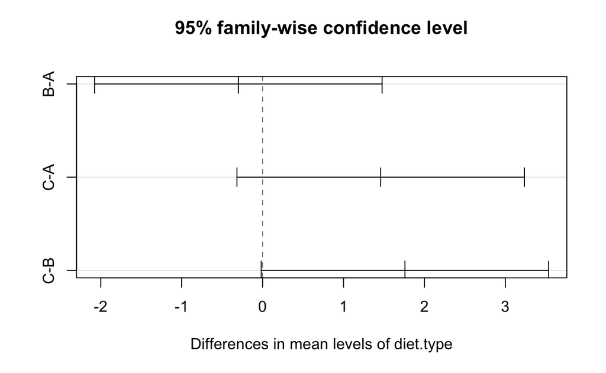

```r
plot(TukeyHSD(fit1))
```

## 9.1 Exercice 8 — Comparaisons multiples sur `PlantGrowth`

1. Réalisez les comparaisons deux à deux par `pairwise.wilcox.test` avec les corrections `"none"`, `"bonferroni"` et `"holm"`. Que remarquez-vous sur les p-values ?
2. Réalisez `TukeyHSD` sur l’ANOVA. Quels groupes diffèrent au risque 5 % ?
3. Pourquoi, après une ANOVA significative, ne conclut-on pas directement en comparant les moyennes « à l’œil » ?

```r
for (m in c("none", "bonferroni", "holm")) {
  cat("\n---", m, "---\n")
  print(pairwise.wilcox.test(PlantGrowth$weight, PlantGrowth$group,
                             p.adjust.method = m))
}
TukeyHSD(aov(weight ~ group, data = PlantGrowth))
```

# 10 ANOVA à deux facteurs (p. 78–80)

On croise deux facteurs : ici le **régime** (indice $k$) et le **sexe** (indice $\ell$). Modèle de Fisher à deux facteurs :

$$Y_{ik\ell}=\mu_{k\ell}+\epsilon_{i(k\ell)}=\mu+\Delta_k+\Delta_\ell+\Delta_{k\ell}+\epsilon_{i(k\ell)},\qquad
\epsilon_{i(k\ell)}\sim\mathcal N(0,\sigma^2),$$

avec les contraintes $\sum n_k\Delta_k=\sum n_\ell\Delta_\ell=\sum n_{k\ell}\Delta_{k\ell}=0$. On teste trois hypothèses :

- $H0_{(1)} : \Delta_k=0\ \forall k$ (pas d’effet du régime) ;
- $H0_{(2)} : \Delta_\ell=0\ \forall \ell$ (pas d’effet du sexe) ;
- $H0_{(3)} : \Delta_{k\ell}=0\ \forall k,\ell$ (pas d’**interaction** : l’effet du régime est le même pour les deux sexes).

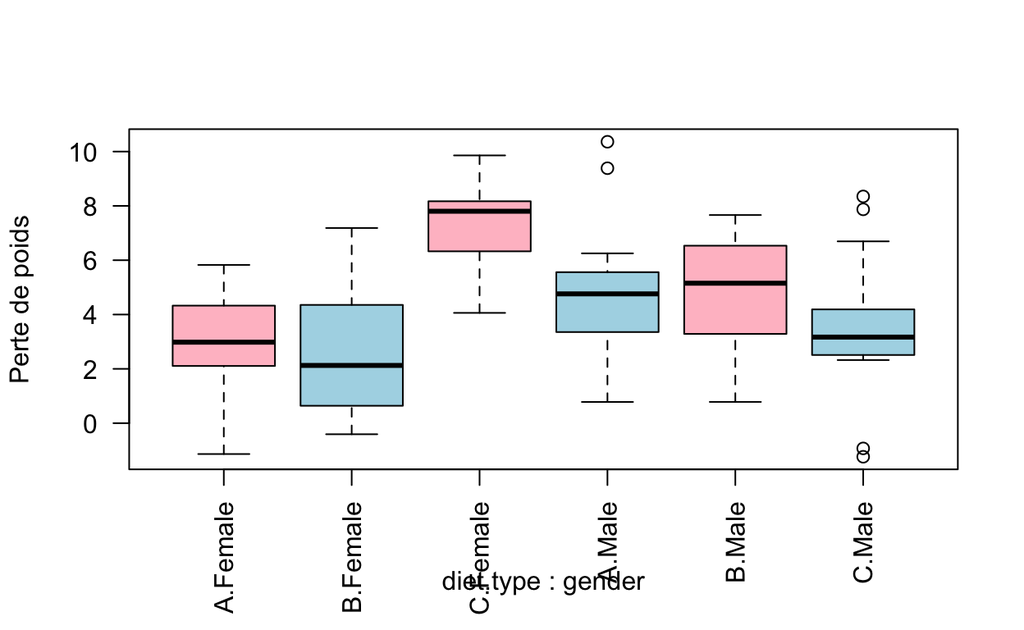

```r
boxplot(weight.loss ~ diet.type + gender, data = diet, las = 2,
        col = rep(c("pink", "lightblue"), 3), ylab = "Perte de poids")
```

```r
fit2 <- aov(weight.loss ~ diet.type * gender, data = diet)
summary(fit2)
```

```
##                  Df Sum Sq Mean Sq F value   Pr(>F)
## diet.type         2   46.0   23.02   4.208   0.0187 *
## gender            1    0.1    0.06   0.011   0.9171
## diet.type:gender  2  143.9   71.95  13.150 1.35e-05 ***
## Residuals        72  393.9    5.47
## ---
## Signif. codes:  0 '***' 0.001 '**' 0.01 '*' 0.05 '.' 0.1 ' ' 1
```

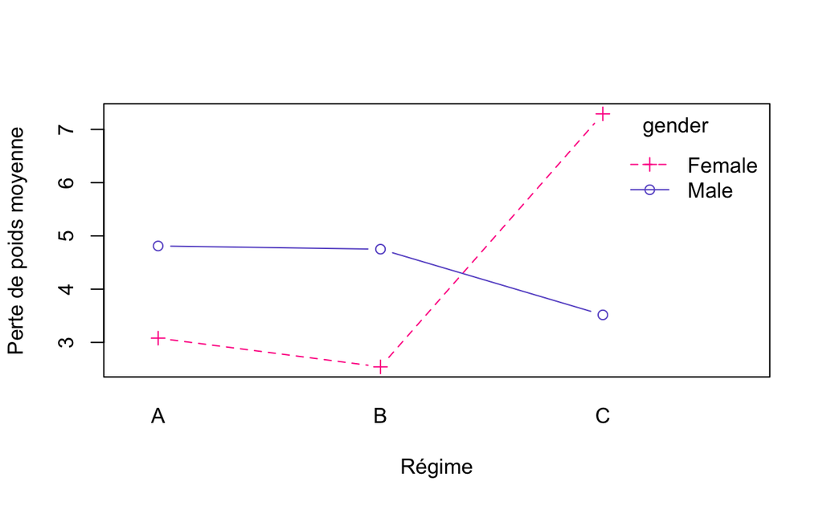

```r
with(diet, interaction.plot(diet.type, gender, weight.loss,
                            type = "b", pch = c(3, 1), col = c("deeppink", "slateblue"),
                            xlab = "Régime", ylab = "Perte de poids moyenne"))
```

Sur le graphique d’interaction, des courbes **parallèles** indiquent l’absence d’interaction ; des courbes qui se croisent ou ne sont pas parallèles indiquent une interaction. Sur la diapositive 79, six scénarios sont illustrés ; l’exercice suivant permet de les simuler.

## 10.1 Exercice 9 — Simuler et lire les scénarios de la diapositive 79

On simule des données équilibrées (13 par cellule) à partir de moyennes de cellules choisies :

```r
simule_2way <- function(mu_diet, mu_gender = c(0, 0), interaction = matrix(0, 3, 2),
                        mu = 2, sigma = 1, n = 13) {
  d <- expand.grid(rep = 1:n, diet.type = c("A", "B", "C"), gender = c("Female", "Male"))
  k <- as.integer(d$diet.type); l <- as.integer(d$gender)
  d$y <- mu + mu_diet[k] + mu_gender[l] + interaction[cbind(k, l)] + rnorm(nrow(d), 0, sigma)
  d$diet.type <- factor(d$diet.type); d$gender <- factor(d$gender)
  d
}
```

1. **Scénario « effet du régime seul »** : `mu_diet = c(-1, 0.5, 0.5)`. Ajustez `aov(y ~ diet.type * gender)`. Quelles lignes de la table sont significatives ?
2. **Scénario « effets additifs régime + sexe »** : ajoutez `mu_gender = c(0.5, -0.5)`. Que devient l’interaction ?
3. **Scénario avec interaction** : ajoutez `interaction = matrix(c(-0.5, 0.5, 0, 0, 0.5, -0.5), 3, 2)`. Tracez le graphique d’interaction et relevez la p-value de la ligne `diet.type:gender`.
4. Quand une interaction est significative, peut-on interpréter « l’effet principal du régime » isolément ? Pourquoi ?

```r
d1 <- simule_2way(mu_diet = c(-1, 0.5, 0.5))
summary(aov(y ~ diet.type * gender, data = d1))

d2 <- simule_2way(mu_diet = c(-1, 0.5, 0.5), mu_gender = c(0.5, -0.5))
...

d3 <- simule_2way(mu_diet = c(-1, 0.5, 0.5), mu_gender = c(0.5, -0.5),
                  interaction = matrix(c(-0.5, 0.5, 0, 0, 0.5, -0.5), 3, 2))
...
with(d3, interaction.plot(diet.type, gender, y))
```

# 11 Exercice de synthèse — `ToothGrowth`

`ToothGrowth` contient la longueur des odontoblastes (`len`) de 60 cobayes, selon le supplément (`supp` : `OJ` jus d’orange, `VC` vitamine C) et la dose (`dose` : 0,5 ; 1 ; 2 mg/jour).

```r
tg <- ToothGrowth
tg$dose <- factor(tg$dose)
str(tg)
```

```
## 'data.frame':    60 obs. of  3 variables:
##  $ len : num  4.2 11.5 7.3 5.8 6.4 10 11.2 11.2 5.2 7 ...
##  $ supp: Factor w/ 2 levels "OJ","VC": 2 2 2 2 2 2 2 2 2 2 ...
##  $ dose: Factor w/ 3 levels "0.5","1","2": 1 1 1 1 1 1 1 1 1 1 ...
```

1. Représentez `len` selon `dose` et `supp` (boîtes à moustaches et graphique d’interaction).
2. Ajustez l’ANOVA à deux facteurs avec interaction. Quelles hypothèses $H0_{(1)}$, $H0_{(2)}$, $H0_{(3)}$ rejette-t-on ?
3. Vérifiez les hypothèses du modèle (résidus : qq-plot, Shapiro-Wilk, Bartlett sur les 6 cellules).
4. Réalisez des comparaisons multiples de Tukey sur le facteur `dose`. Concluez en termes cliniques (dans le contexte de l’expérience).
5. Si les hypothèses de normalité ou d’homogénéité vous semblent douteuses, que proposez-vous (Kruskal-Wallis par supplément, Welch) ?

```r
boxplot(len ~ dose + supp, data = tg, las = 2)
with(tg, interaction.plot(dose, supp, len))

fit_tg <- aov(len ~ dose * supp, data = tg)
summary(fit_tg)

...
```

# 12 Corrigés

> Essayez d’abord les exercices avant de lire cette section.

## 12.1 Corrigé de l’exercice 1

```r
pg2 <- subset(PlantGrowth, group %in% c("ctrl", "trt1"))
pg2$group <- droplevels(pg2$group)

tt <- t.test(weight ~ group, data = pg2, var.equal = TRUE)
av <- aov(weight ~ group, data = pg2)
F_obs <- summary(av)[[1]][["F value"]][1]

c(p_student = tt$p.value, p_anova = summary(av)[[1]][["Pr(>F)"]][1])
```

```
## p_student   p_anova
## 0.2490232 0.2490232
```

```r
c(t_au_carre = unname(tt$statistic)^2, F = F_obs)
```

```
## t_au_carre          F
##   1.419101   1.419101
```

```r
coef(lm(weight ~ group, data = pg2))
```

```
## (Intercept)   grouptrt1
##       5.032      -0.371
```

Les deux p-values sont identiques et $F=t^2$ : avec deux groupes, l’ANOVA de Fisher et le test de Student (variances égales) sont **le même test**. Le coefficient `grouptrt1` est $\hat\Delta=\bar x_{trt1}-\bar x_{ctrl}$ (le groupe de référence est `ctrl`) ; il est négatif car le poids moyen de `trt1` est plus faible que celui du contrôle.

## 12.2 Corrigé de l’exercice 2

```r
y <- PlantGrowth$weight
g <- PlantGrowth$group
N <- length(y); K <- nlevels(g)
ybar   <- mean(y)
ybar_k <- tapply(y, g, mean)
n_k    <- tapply(y, g, length)

SST <- sum((y - ybar)^2)
B   <- sum(n_k * (ybar_k - ybar)^2)
W   <- sum((y - ybar_k[g])^2)
c(SST = SST, B_plus_W = B + W, B = B, W = W)
```

```
##      SST B_plus_W        B        W
## 14.25843 14.25843  3.76634 10.49209
```

```r
F_obs <- (B / (K - 1)) / (W / (N - K))
p_val <- pf(F_obs, df1 = K - 1, df2 = N - K, lower.tail = FALSE)
c(F = F_obs, p = p_val)
```

```
##          F          p
## 4.84608786 0.01590996
```

```r
summary(aov(weight ~ group, data = PlantGrowth))
```

```
##             Df Sum Sq Mean Sq F value Pr(>F)
## group        2  3.766  1.8832   4.846 0.0159 *
## Residuals   27 10.492  0.3886
## ---
## Signif. codes:  0 '***' 0.001 '**' 0.01 '*' 0.05 '.' 0.1 ' ' 1
```

On retrouve $SST=B+W$ (décomposition orthogonale) et les mêmes $F$ et p-value que `aov`.

## 12.3 Corrigé de l’exercice 3

```r
nsim <- 2000
res <- replicate(nsim, {
  d <- data.frame(y = rnorm(30), g = factor(rep(1:3, each = 10)))
  p_anova <- summary(aov(y ~ g, data = d))[[1]][["Pr(>F)"]][1]
  p_pair  <- pairwise.t.test(d$y, d$g, p.adjust.method = "none")$p.value
  p_bonf  <- pairwise.t.test(d$y, d$g, p.adjust.method = "bonferroni")$p.value
  c(anova = p_anova < 0.05,
    paires_sans_correction = any(p_pair < 0.05, na.rm = TRUE),
    paires_bonferroni = any(p_bonf < 0.05, na.rm = TRUE))
})
round(rowMeans(res), 3)
```

```
##                  anova paires_sans_correction      paires_bonferroni
##                  0.053                  0.117                  0.047
```

```r
1 - (1 - 0.05)^3
```

```
## [1] 0.142625
```

L’ANOVA rejette à tort environ 5 % du temps (niveau respecté). Les 3 tests par paires sans correction rejettent à tort environ 12–14 % du temps (proche de $1-(1-0{,}05)^3\approx0{,}14$ ; un peu moins car les 3 tests ne sont pas indépendants). Avec Bonferroni, le niveau global est de nouveau proche (ou en dessous) de 5 %.

## 12.4 Corrigé de l’exercice 4

```r
y <- diet$weight.loss; g <- diet$diet.type
N <- length(y); K <- nlevels(g)
n_k <- tapply(y, g, length); m_k <- tapply(y, g, mean); v_k <- tapply(y, g, var)
ybar <- mean(y)

s2_Ybar <- sum(n_k / N * (m_k - ybar)^2) / (K - 1)
s2_p    <- sum((n_k - 1) * v_k) / (N - K)
F_obs   <- N * s2_Ybar / s2_p
F_obs
```

```
## [1] 3.210279
```

```r
summary(fit1)[[1]][["F value"]][1]
```

```
## [1] 3.210279
```

```r
SSB <- sum(n_k * (m_k - ybar)^2); SST <- sum((y - ybar)^2)
eta2 <- SSB / SST
eta2
```

```
## [1] 0.07885672
```

Les deux valeurs de $F$ coïncident. $\eta^2$ mesure la proportion de la variabilité de la perte de poids expliquée par le régime. Avec une p-value inférieure à 0,05, on rejette l’égalité des moyennes : au risque 5 %, la perte de poids moyenne n’est pas la même pour les trois régimes (au moins un diffère des autres).

## 12.5 Corrigé de l’exercice 5

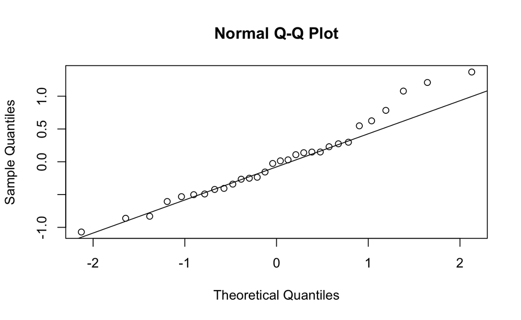

```r
fit_pg <- aov(weight ~ group, data = PlantGrowth)
r <- residuals(fit_pg)
qqnorm(r); qqline(r)
```

```r
shapiro.test(r)
```

```
##
##  Shapiro-Wilk normality test
##
## data:  r
## W = 0.96607, p-value = 0.4379
```

```r
bartlett.test(weight ~ group, data = PlantGrowth)
```

```
##
##  Bartlett test of homogeneity of variances
##
## data:  weight by group
## Bartlett's K-squared = 2.8786, df = 2, p-value = 0.2371
```

Le qq-plot est proche de la diagonale, Shapiro-Wilk ne rejette pas la normalité et Bartlett ne rejette pas l’égalité des variances : les conditions d’application de l’ANOVA de Fisher sont raisonnablement satisfaites (à nuancer : 10 observations par groupe seulement, donc peu de puissance pour détecter un écart).

## 12.6 Corrigé de l’exercice 6

```r
sim_het <- function() {
  data.frame(
    y = c(rnorm(10, 0, 1), rnorm(10, 0, 3), rnorm(40, 0, 6)),
    g = factor(rep(c("g1", "g2", "g3"), times = c(10, 10, 40)))
  )
}
res <- replicate(2000, {
  d <- sim_het()
  c(fisher = oneway.test(y ~ g, data = d, var.equal = TRUE)$p.value < 0.05,
    welch  = oneway.test(y ~ g, data = d, var.equal = FALSE)$p.value < 0.05)
})
rowMeans(res)
```

```
## fisher  welch
##  0.001  0.048
```

## 12.7 Corrigé de l’exercice 7

```r
y <- PlantGrowth$weight; g <- PlantGrowth$group
N <- length(y); K <- nlevels(g)
r   <- rank(y)
R_k <- tapply(r, g, sum)
n_k <- tapply(r, g, length)

S0 <- 12 / (N * (N + 1)) * sum(R_k^2 / n_k) - 3 * (N + 1)
t_v <- table(y)
C   <- 1 - sum(t_v^3 - t_v) / (N^3 - N)
S   <- S0 / C
c(S_sans_correction = S0, S_corrige = S)
```

```
## S_sans_correction         S_corrige
##          7.986452          7.988229
```

```r
pchisq(S, df = K - 1, lower.tail = FALSE)
```

```
## [1] 0.01842376
```

```r
kruskal.test(weight ~ group, data = PlantGrowth)
```

```
##
##  Kruskal-Wallis rank sum test
##
## data:  weight by group
## Kruskal-Wallis chi-squared = 7.9882, df = 2, p-value = 0.01842
```

La statistique corrigée correspond à celle de `kruskal.test` (chi² ≈ 7,99, p ≈ 0,018, comme dans le cours). Sans ex æquo, la correction vaut 1.

## 12.8 Corrigé de l’exercice 8

```r
for (m in c("none", "bonferroni", "holm")) {
  cat("\n---", m, "---\n")
  print(pairwise.wilcox.test(PlantGrowth$weight, PlantGrowth$group,
                             p.adjust.method = m))
}
```

```
##
## --- none ---
##
##  Pairwise comparisons using Wilcoxon rank sum exact test
##
## data:  PlantGrowth$weight and PlantGrowth$group
##
##      ctrl   trt1
## trt1 0.1968 -
## trt2 0.0630 0.0089
##
## P value adjustment method: none
##
## --- bonferroni ---
##
##  Pairwise comparisons using Wilcoxon rank sum exact test
##
## data:  PlantGrowth$weight and PlantGrowth$group
##
##      ctrl  trt1
## trt1 0.590 -
## trt2 0.189 0.027
##
## P value adjustment method: bonferroni
##
## --- holm ---
##
##  Pairwise comparisons using Wilcoxon rank sum exact test
##
## data:  PlantGrowth$weight and PlantGrowth$group
##
##      ctrl  trt1
## trt1 0.197 -
## trt2 0.126 0.027
##
## P value adjustment method: holm
```

```r
TukeyHSD(aov(weight ~ group, data = PlantGrowth))
```

```
##   Tukey multiple comparisons of means
##     95% family-wise confidence level
##
## Fit: aov(formula = weight ~ group, data = PlantGrowth)
##
## $group
##             diff        lwr       upr     p adj
## trt1-ctrl -0.371 -1.0622161 0.3202161 0.3908711
## trt2-ctrl  0.494 -0.1972161 1.1852161 0.1979960
## trt2-trt1  0.865  0.1737839 1.5562161 0.0120064
```

Les corrections augmentent les p-values (Bonferroni : p × nombre de comparaisons, plafonné à 1 ; Holm est un peu moins conservative). La différence `trt1`–`trt2` est la plus nette ; `ctrl` ne diffère significativement d’aucun traitement après correction. Le test de Tukey conduit à la même conclusion. Comparer les moyennes « à l’œil » ou faire des tests sans correction fait exploser le risque global de première espèce (cf. exercice 3).

## 12.9 Corrigé de l’exercice 9

```r
simule_2way <- function(mu_diet, mu_gender = c(0, 0), interaction = matrix(0, 3, 2),
                        mu = 2, sigma = 1, n = 13) {
  d <- expand.grid(rep = 1:n, diet.type = c("A", "B", "C"), gender = c("Female", "Male"))
  k <- as.integer(d$diet.type); l <- as.integer(d$gender)
  d$y <- mu + mu_diet[k] + mu_gender[l] + interaction[cbind(k, l)] + rnorm(nrow(d), 0, sigma)
  d$diet.type <- factor(d$diet.type); d$gender <- factor(d$gender)
  d
}

d1 <- simule_2way(mu_diet = c(-1, 0.5, 0.5))
summary(aov(y ~ diet.type * gender, data = d1))
```

```
##                  Df Sum Sq Mean Sq F value   Pr(>F)
## diet.type         2  45.15  22.574  17.167 8.01e-07 ***
## gender            1   5.20   5.196   3.952   0.0506 .
## diet.type:gender  2   2.44   1.219   0.927   0.4004
## Residuals        72  94.68   1.315
## ---
## Signif. codes:  0 '***' 0.001 '**' 0.01 '*' 0.05 '.' 0.1 ' ' 1
```

```r
d2 <- simule_2way(mu_diet = c(-1, 0.5, 0.5), mu_gender = c(0.5, -0.5))
summary(aov(y ~ diet.type * gender, data = d2))
```

```
##                  Df Sum Sq Mean Sq F value   Pr(>F)
## diet.type         2  30.78  15.392  18.812 2.68e-07 ***
## gender            1  21.23  21.233  25.951 2.71e-06 ***
## diet.type:gender  2   0.19   0.096   0.117     0.89
## Residuals        72  58.91   0.818
## ---
## Signif. codes:  0 '***' 0.001 '**' 0.01 '*' 0.05 '.' 0.1 ' ' 1
```

```r
d3 <- simule_2way(mu_diet = c(-1, 0.5, 0.5), mu_gender = c(0.5, -0.5),
                  interaction = matrix(c(-0.5, 0.5, 0, 0, 0.5, -0.5), 3, 2))
summary(aov(y ~ diet.type * gender, data = d3))
```

```
##                  Df Sum Sq Mean Sq F value   Pr(>F)
## diet.type         2  40.53  20.264  22.103 3.28e-08 ***
## gender            1   6.75   6.747   7.360  0.00834 **
## diet.type:gender  2  10.04   5.022   5.478  0.00610 **
## Residuals        72  66.01   0.917
## ---
## Signif. codes:  0 '***' 0.001 '**' 0.01 '*' 0.05 '.' 0.1 ' ' 1
```

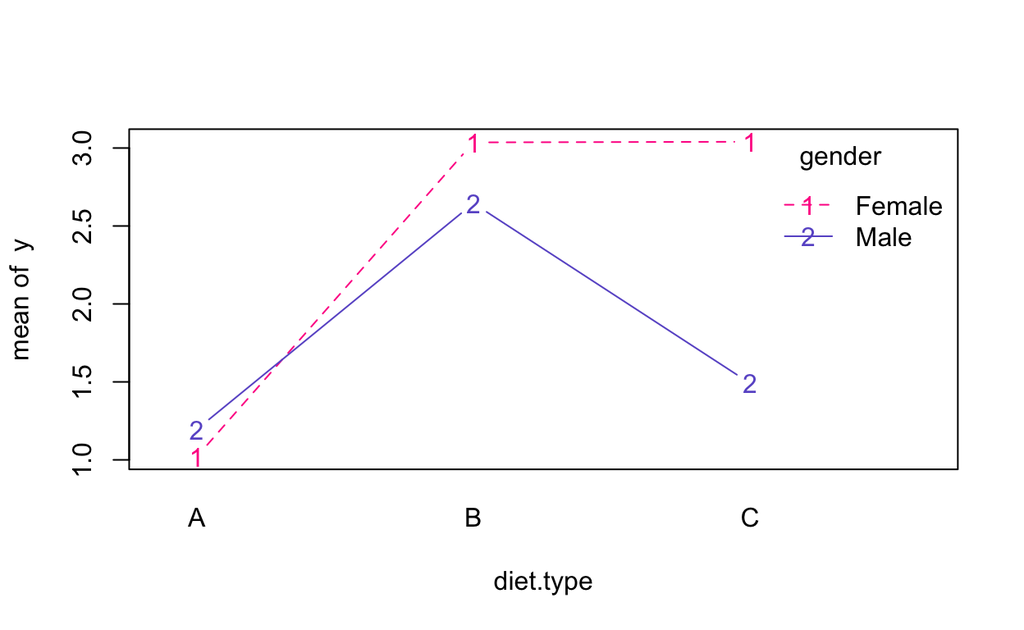

```r
with(d3, interaction.plot(diet.type, gender, y, type = "b",
                          col = c("deeppink", "slateblue")))
```

1. Seule la ligne `diet.type` est significative.
2. `diet.type` et `gender` sont significatifs, mais pas l’interaction : les courbes du graphique d’interaction sont parallèles (effets **additifs**).
3. L’interaction (`diet.type:gender`) devient détectable (si $\sigma$ est assez petit ou $n$ assez grand) : les courbes ne sont plus parallèles.
4. En présence d’interaction significative, l’effet du régime **dépend** du sexe : on ne peut pas interpréter l’effet principal isolément ; on étudie l’effet du régime séparément pour chaque sexe (ou on décrit les différences par cellule).

## 12.10 Corrigé de l’exercice de synthèse (`ToothGrowth`)

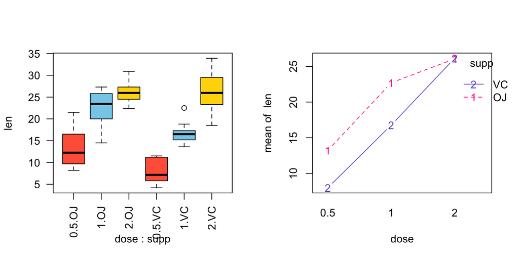

```r
tg <- ToothGrowth
tg$dose <- factor(tg$dose)

par(mfrow = c(1, 2))
boxplot(len ~ dose + supp, data = tg, las = 2, col = rep(c("tomato", "skyblue", "gold"), 2))
with(tg, interaction.plot(dose, supp, len, type = "b",
                          col = c("deeppink", "slateblue")))
```

```r
par(mfrow = c(1, 1))

fit_tg <- aov(len ~ dose * supp, data = tg)
summary(fit_tg)
```

```
##             Df Sum Sq Mean Sq F value   Pr(>F)
## dose         2 2426.4  1213.2  92.000  < 2e-16 ***
## supp         1  205.4   205.4  15.572 0.000231 ***
## dose:supp    2  108.3    54.2   4.107 0.021860 *
## Residuals   54  712.1    13.2
## ---
## Signif. codes:  0 '***' 0.001 '**' 0.01 '*' 0.05 '.' 0.1 ' ' 1
```

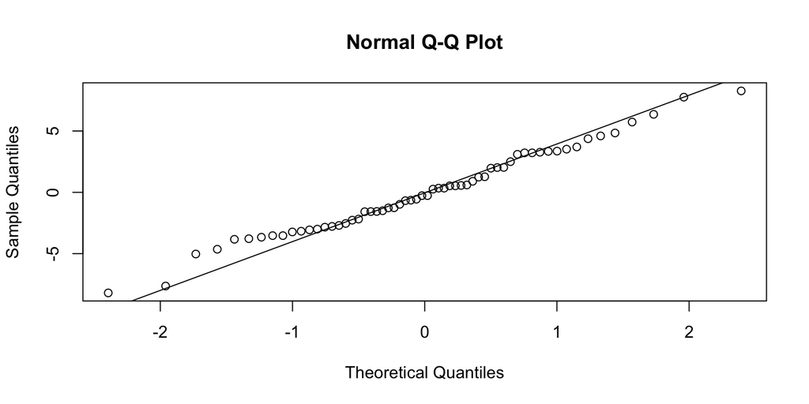

```r
# Hypothèses du modèle
r <- residuals(fit_tg)
qqnorm(r); qqline(r)
```

```r
shapiro.test(r)
```

```
##
##  Shapiro-Wilk normality test
##
## data:  r
## W = 0.98499, p-value = 0.6694
```

```r
bartlett.test(len ~ interaction(dose, supp), data = tg)
```

```
##
##  Bartlett test of homogeneity of variances
##
## data:  len by interaction(dose, supp)
## Bartlett's K-squared = 6.9273, df = 5, p-value = 0.2261
```

```r
# Comparaisons multiples sur la dose
TukeyHSD(fit_tg, which = "dose")
```

```
##   Tukey multiple comparisons of means
##     95% family-wise confidence level
##
## Fit: aov(formula = len ~ dose * supp, data = tg)
##
## $dose
##         diff       lwr       upr   p adj
## 1-0.5  9.130  6.362488 11.897512 0.0e+00
## 2-0.5 15.495 12.727488 18.262512 0.0e+00
## 2-1    6.365  3.597488  9.132512 2.7e-06
```

```r
# Alternatives si besoin
oneway.test(len ~ dose, data = subset(tg, supp == "OJ"), var.equal = FALSE)
```

```
##
##  One-way analysis of means (not assuming equal variances)
##
## data:  len and dose
## F = 29.404, num df = 2.000, denom df = 17.069, p-value = 2.954e-06
```

```r
kruskal.test(len ~ dose, data = subset(tg, supp == "VC"))
```

```
##
##  Kruskal-Wallis rank sum test
##
## data:  len by dose
## Kruskal-Wallis chi-squared = 25.072, df = 2, p-value = 3.594e-06
```

Lecture attendue : la dose a un effet très significatif (la longueur augmente avec la dose), le supplément a aussi un effet significatif et l’interaction `dose:supp` est significative : l’avantage du jus d’orange sur la vitamine C est marqué pour les doses faibles et disparaît à la dose de 2 mg (les courbes se rejoignent). L’interaction étant significative, on interprète l’effet du supplément **dose par dose**. Les résidus sont raisonnablement gaussiens ; l’homogénéité des variances est à surveiller (voir Bartlett). Si elle est douteuse, on peut utiliser Welch ou Kruskal-Wallis dans chaque sous-groupe, avec correction de multiplicité.

# 13 Récapitulatif

| Situation | Test | Fonction R |
| --- | --- | --- |
| 2 moyennes, variances égales, gaussien | Student | `t.test(..., var.equal = TRUE)` |
| $K\ge 3$ moyennes, variances égales, gaussien | ANOVA de Fisher | `aov()`, `summary()` |
| $K\ge 3$ moyennes, variances inégales | ANOVA de Welch | `oneway.test(..., var.equal = FALSE)` |
| $K\ge 3$ groupes, sans hypothèse de loi | Kruskal-Wallis | `kruskal.test()` |
| Normalité des résidus | Shapiro-Wilk, qq-plot | `shapiro.test()`, `qqnorm()` |
| Égalité des variances ($K\ge 3$) | Bartlett | `bartlett.test()` |
| Quelles paires diffèrent ? | Bonferroni, Šidák, Tukey | `pairwise.t.test()`, `TukeyHSD()`, `p.adjust()` |
| 2 facteurs + interaction | ANOVA à deux facteurs | `aov(y ~ A * B)` |